# Storm Events Analysis in the United States

Anders Cui

Sunday, August 24, 2014

## Synopisis

In this document, I will show you an analysis of storms and other severe weather events in the United States. The data set comes from NOAA which tracks characteristics of major storms and weather events in the United States during 1950 to 2011.

At the end of this document, I will show you:

- Which types of events are most harmful for population health
- Which types of events have the greatest economic consequences

## Data Processing

First, let’s read the data set.

```r
setwd("D:/andersc/r/")
data <- read.csv("StormData.csv", stringsAsFactors = FALSE)
```

After checking the variable names, I extracted the variables we need in this analysis, their meanings are briefly listed below:

- BGN_DATE: begin date of the event
- EVTYPE: event type
- FATALITIES: fatilities in the event
- INJURIES: injuries in the event
- PROPDMG: property damages in the event
- PROPDMGEXP: property damage exponents
- CROPDMG: crop damages in the event
- CROPDMGEXP: crop damage exponents

The basic process is that I summed up the **fatilities** and **injuries** as **Population Health**, and the **property** damages and **crop** damages as **Economic Consequences**.

```r
vars <- c("BGN_DATE", "EVTYPE", "FATALITIES", "INJURIES", "PROPDMG",
          "PROPDMGEXP", "CROPDMG", "CROPDMGEXP")

# tidy is the cleaned data set.
tidy <- data[vars]
tidy$date <- as.Date(tidy$BGN_DATE, "%m/%d/%Y %H:%M:%S")

# calculate harms to population health
tidy$population_health <- tidy$FATALITIES + tidy$INJURIES
```

Next, I use the following code to view the values of these exponents.

```r
unique(tidy$PROPDMGEXP)
```

```
##  [1] "K" "M" ""  "B" "m" "+" "0" "5" "6" "?" "4" "2" "3" "h" "7" "H" "-"
## [18] "1" "8"
```

```r
unique(tidy$CROPDMGEXP)
```

```
## [1] ""  "M" "K" "m" "B" "?" "0" "k" "2"
```

We can see that some values are characters, some others are numbers, so we need to uniform them.

```r
# convert damage exponents to a uniform numberical representation
# properties damage
tidy$PROPDMGEXP[(tidy$PROPDMGEXP == "") |
                    (tidy$PROPDMGEXP == "+") |
                    (tidy$PROPDMGEXP == "-") |
                    (tidy$PROPDMGEXP == "?")] <- 0

tidy$PROPDMGEXP[(tidy$PROPDMGEXP == "h") |
                    (tidy$PROPDMGEXP == "H")] <- 2

tidy$PROPDMGEXP[(tidy$PROPDMGEXP == "k") |
                    (tidy$PROPDMGEXP == "K")] <- 3

tidy$PROPDMGEXP[(tidy$PROPDMGEXP == "m") |
                    (tidy$PROPDMGEXP == "M")] <- 6

tidy$PROPDMGEXP[(tidy$PROPDMGEXP == "B")] <- 9

# crop damages
tidy$CROPDMGEXP[(tidy$CROPDMGEXP == "") |
                    (tidy$CROPDMGEXP == "?")] <- 0

tidy$CROPDMGEXP[(tidy$CROPDMGEXP == "k") |
                    (tidy$CROPDMGEXP == "K")] <- 3

tidy$CROPDMGEXP[(tidy$CROPDMGEXP == "m") |
                    (tidy$CROPDMGEXP == "M")] <- 6

tidy$CROPDMGEXP[(tidy$CROPDMGEXP == "B")] <- 9

# convert to numbers
tidy$PROPDMGEXP <- as.integer(tidy$PROPDMGEXP)
tidy$CROPDMGEXP <- as.integer(tidy$CROPDMGEXP)

tidy$eco_dmg <- tidy$PROPDMG * 10^tidy$PROPDMGEXP +
                   tidy$CROPDMG * 10^tidy$CROPDMGEXP

health <- sort(tapply(tidy$population_health, tidy$EVTYPE, sum), decreasing = T)
eco_dmg <- sort(tapply(tidy$eco_dmg, tidy$EVTYPE, sum), decreasing = T)
```

Now we’ve got all the data we need.

## Results

I will show the results to you by plots which plotted by **ggplot2** package, so let’s import the package.

```r
library(ggplot2)
```

Let’s see the bar plot of top 5 most harmful event types to population health.

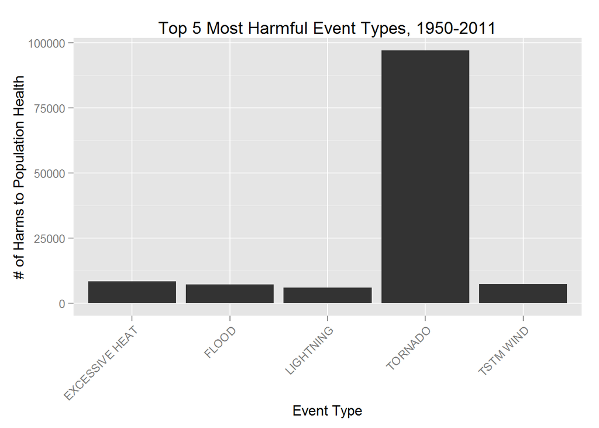

```r
# population health
health_top5 <- health[1:5]

types <- as.vector(names(head(health_top5)))
values <- as.vector(health_top5)
df <- data.frame(types, values)
ggplot(data = df, aes(x = df$types, y = df$values)) +
    geom_bar(stat = "identity") +
    theme(axis.text.x = element_text(angle = 45, hjust = 1)) +
    xlab("Event Type") + ylab("# of Harms to Population Health") +
    ggtitle("Top 5 Most Harmful Event Types, 1950-2011")
```

It’s obvious that **TORNADO** event type is the most harmful one, which much worse than events.

Finally, let’s take a look at the bar plot of top 5 event types which caused highest economic damages.

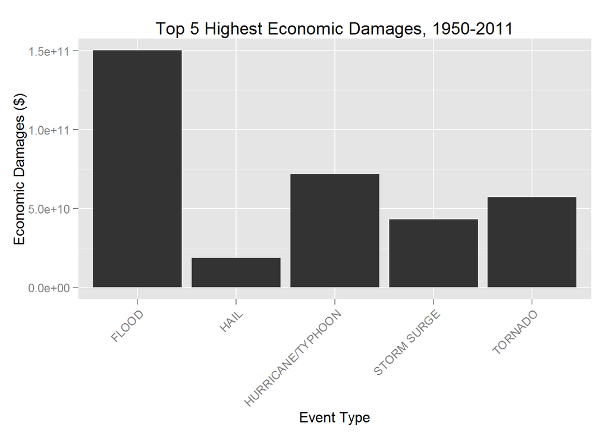

```r
# economic consequences
eco_top5 <- eco_dmg[1:5]

types <- as.vector(names(head(eco_top5)))
values <- as.vector(eco_top5)
df <- data.frame(types, values)
ggplot(data = df, aes(x = df$types, y = df$values)) +
    geom_bar(stat = "identity") +
    theme(axis.text.x = element_text(angle = 45, hjust = 1)) +
    xlab("Event Type") + ylab("Economic Damages ($)") +
    ggtitle("Top 5 Highest Economic Damages, 1950-2011")
```

As per the bar plot, **FLOOD** event type caused highest economic damages.